# Data 621 Assignment 1

Mark Gonsalves, Joshua Hummell, Claire Meyer, Chinedu Onyeka, Rathish Parayil Sasidharan

2/23/2022

# Assignment One: Baseball

### Data Exploration

This assignment reviews a baseball dataset, which looks at teams across a number of different features. We’ll be building a number of linear regression models and comparing their efficacy.

To start, we will explore the dataset: its shape, composition, and any information that may help with future data processing and model building.

```r
#eval <- getURL("https://raw.githubusercontent.com/cmm6/data608/main/moneyball-evaluation-data.csv",.opts=curlOptions(followlocation = TRUE))
#train <- getURL("https://raw.githubusercontent.com/cmm6/data608/main/moneyball-training-data.csv",.opts=curlOptions(followlocation = TRUE))
baseball_eval <- read.csv("https://raw.githubusercontent.com/cmm6/data608/main/moneyball-evaluation-data.csv", header=TRUE, sep = ",")
baseball_training <- read.csv("https://raw.githubusercontent.com/cmm6/data608/main/moneyball-training-data.csv", header=TRUE, sep = ",")

baseball_eval <- subset(baseball_eval, select = -c(INDEX) )
baseball_training = subset(baseball_training, select = -c(INDEX) )

print(dim(baseball_training))
```

```
## [1] 2276   16
```

```r
print(head(baseball_training))
```

```
##   TARGET_WINS TEAM_BATTING_H TEAM_BATTING_2B TEAM_BATTING_3B TEAM_BATTING_HR
## 1          39           1445             194              39              13
## 2          70           1339             219              22             190
## 3          86           1377             232              35             137
## 4          70           1387             209              38              96
## 5          82           1297             186              27             102
## 6          75           1279             200              36              92
##   TEAM_BATTING_BB TEAM_BATTING_SO TEAM_BASERUN_SB TEAM_BASERUN_CS
## 1             143             842              NA              NA
## 2             685            1075              37              28
## 3             602             917              46              27
## 4             451             922              43              30
## 5             472             920              49              39
## 6             443             973             107              59
##   TEAM_BATTING_HBP TEAM_PITCHING_H TEAM_PITCHING_HR TEAM_PITCHING_BB
## 1               NA            9364               84              927
## 2               NA            1347              191              689
## 3               NA            1377              137              602
## 4               NA            1396               97              454
## 5               NA            1297              102              472
## 6               NA            1279               92              443
##   TEAM_PITCHING_SO TEAM_FIELDING_E TEAM_FIELDING_DP
## 1             5456            1011               NA
## 2             1082             193              155
## 3              917             175              153
## 4              928             164              156
## 5              920             138              168
## 6              973             123              149
```

First, we’ll use summary() to get a sense of the type and values for each field.

Right away, we can see several fields have NA values, including the majority of TEAM_BATTING_HBP. We can try different ways to handle these in later model development, e.g. removing entirely vs. replacing with mean, etc.

```r
summary(baseball_training)
```

```
##   TARGET_WINS     TEAM_BATTING_H TEAM_BATTING_2B TEAM_BATTING_3B
##  Min.   :  0.00   Min.   : 891   Min.   : 69.0   Min.   :  0.00
##  1st Qu.: 71.00   1st Qu.:1383   1st Qu.:208.0   1st Qu.: 34.00
##  Median : 82.00   Median :1454   Median :238.0   Median : 47.00
##  Mean   : 80.79   Mean   :1469   Mean   :241.2   Mean   : 55.25
##  3rd Qu.: 92.00   3rd Qu.:1537   3rd Qu.:273.0   3rd Qu.: 72.00
##  Max.   :146.00   Max.   :2554   Max.   :458.0   Max.   :223.00
##
##  TEAM_BATTING_HR  TEAM_BATTING_BB TEAM_BATTING_SO  TEAM_BASERUN_SB
##  Min.   :  0.00   Min.   :  0.0   Min.   :   0.0   Min.   :  0.0
##  1st Qu.: 42.00   1st Qu.:451.0   1st Qu.: 548.0   1st Qu.: 66.0
##  Median :102.00   Median :512.0   Median : 750.0   Median :101.0
##  Mean   : 99.61   Mean   :501.6   Mean   : 735.6   Mean   :124.8
##  3rd Qu.:147.00   3rd Qu.:580.0   3rd Qu.: 930.0   3rd Qu.:156.0
##  Max.   :264.00   Max.   :878.0   Max.   :1399.0   Max.   :697.0
##                                   NA's   :102      NA's   :131
##  TEAM_BASERUN_CS TEAM_BATTING_HBP TEAM_PITCHING_H TEAM_PITCHING_HR
##  Min.   :  0.0   Min.   :29.00    Min.   : 1137   Min.   :  0.0
##  1st Qu.: 38.0   1st Qu.:50.50    1st Qu.: 1419   1st Qu.: 50.0
##  Median : 49.0   Median :58.00    Median : 1518   Median :107.0
##  Mean   : 52.8   Mean   :59.36    Mean   : 1779   Mean   :105.7
##  3rd Qu.: 62.0   3rd Qu.:67.00    3rd Qu.: 1682   3rd Qu.:150.0
##  Max.   :201.0   Max.   :95.00    Max.   :30132   Max.   :343.0
##  NA's   :772     NA's   :2085
##  TEAM_PITCHING_BB TEAM_PITCHING_SO  TEAM_FIELDING_E  TEAM_FIELDING_DP
##  Min.   :   0.0   Min.   :    0.0   Min.   :  65.0   Min.   : 52.0
##  1st Qu.: 476.0   1st Qu.:  615.0   1st Qu.: 127.0   1st Qu.:131.0
##  Median : 536.5   Median :  813.5   Median : 159.0   Median :149.0
##  Mean   : 553.0   Mean   :  817.7   Mean   : 246.5   Mean   :146.4
##  3rd Qu.: 611.0   3rd Qu.:  968.0   3rd Qu.: 249.2   3rd Qu.:164.0
##  Max.   :3645.0   Max.   :19278.0   Max.   :1898.0   Max.   :228.0
##                   NA's   :102                        NA's   :286
```

One of the key requirements of linear regression is a linear relationship between the explanatory and target variables. Digging into these relationships using scatter plot, it looks like TEAM_BATTING_SO, TEAM_BATTING_BB, and TEAM_PITCHING_SO have clear clustering around 0 and may not be linear.

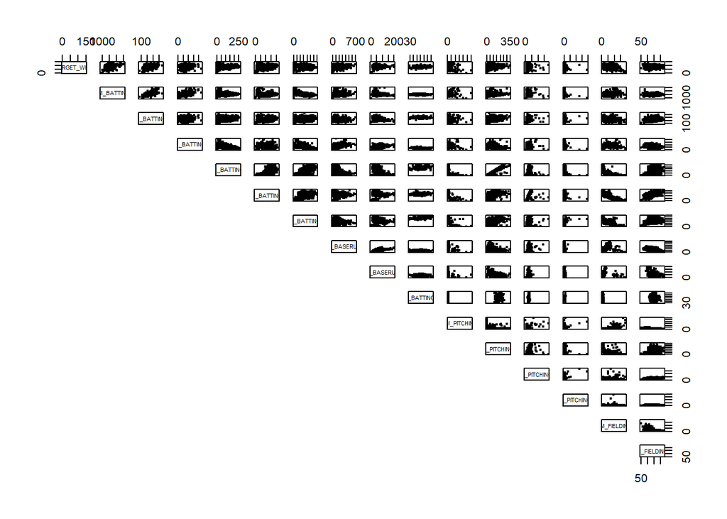

```r
pairs(baseball_training, lower.panel = NULL, cex = 0.4, cex.labels=0.5)
```

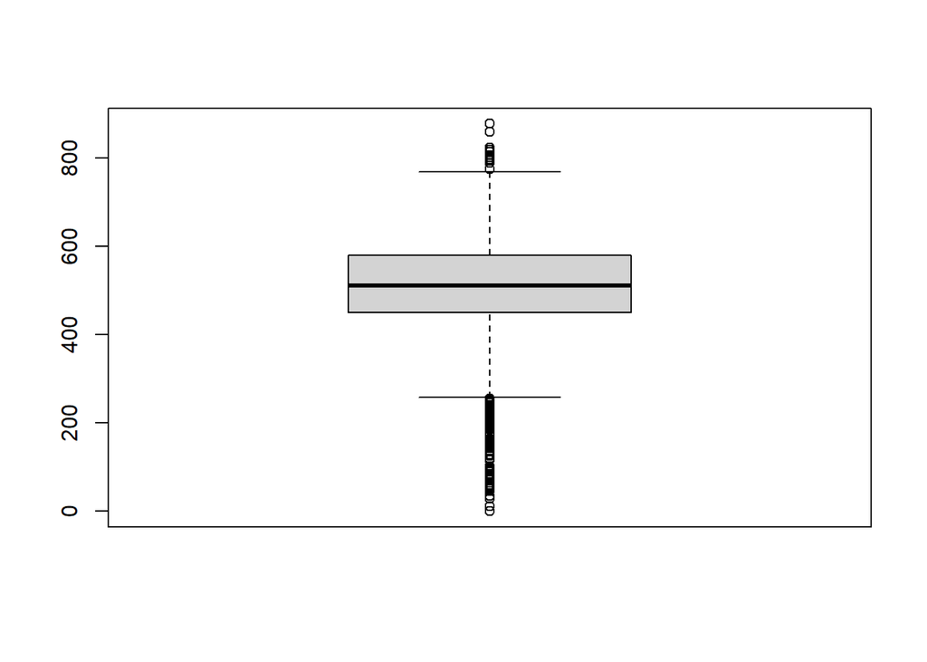

```r
boxplot(baseball_training$TEAM_BATTING_BB)
```

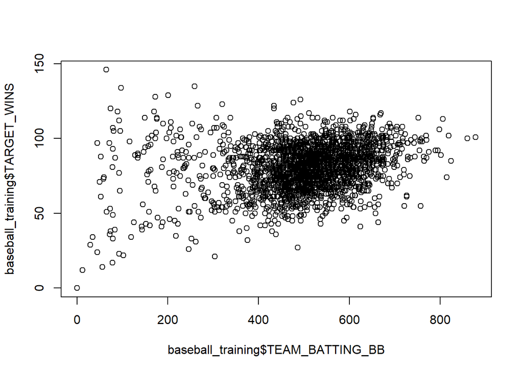

```r
plot(baseball_training$TEAM_BATTING_BB,baseball_training$TARGET_WINS)
```

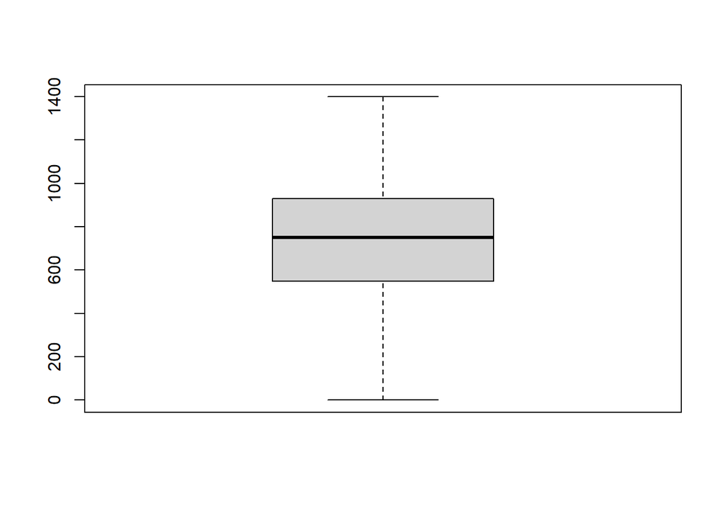

```r
boxplot(baseball_training$TEAM_BATTING_SO)
```

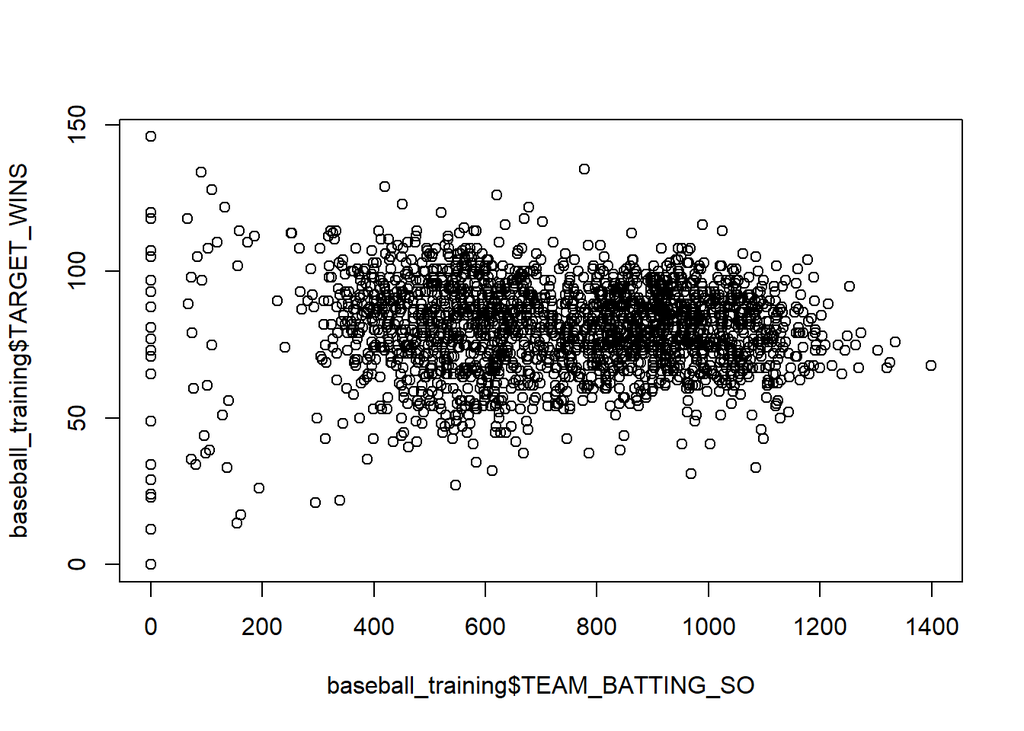

```r
plot(baseball_training$TEAM_BATTING_SO,baseball_training$TARGET_WINS)
```

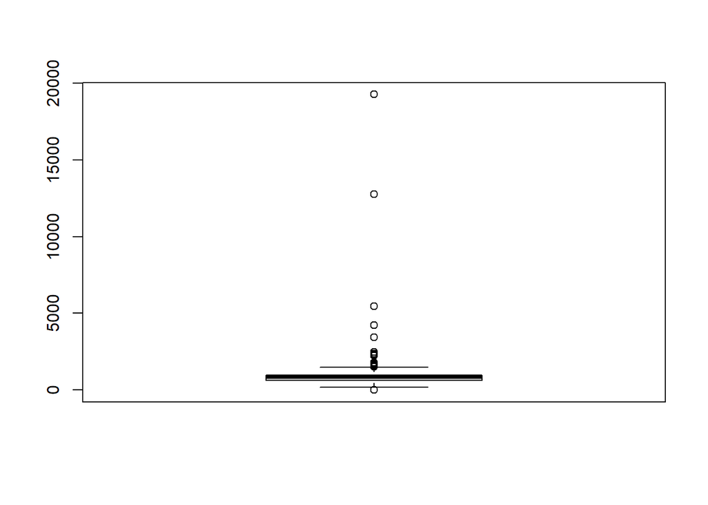

```r
boxplot(baseball_training$TEAM_PITCHING_SO)
```

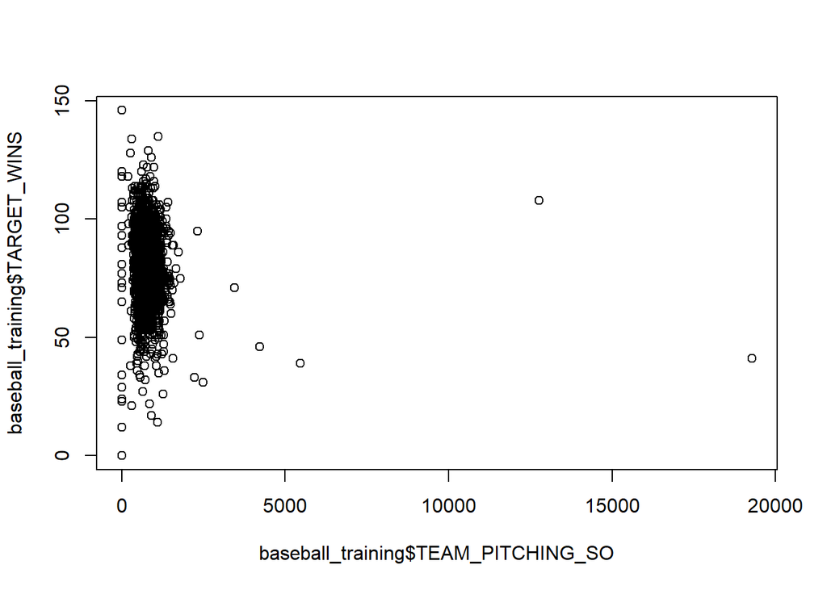

```r
plot(baseball_training$TEAM_PITCHING_SO,baseball_training$TARGET_WINS)
```

These features and other nonlinearity can be kept in mind in executing the model.

Also valauble is building a correlation matrix. This serves two purposes - to show which features correlate highly to the Target variable, and to reduce potential for collinearity if two features are not offering distinct value to the model. NA values are omitted.

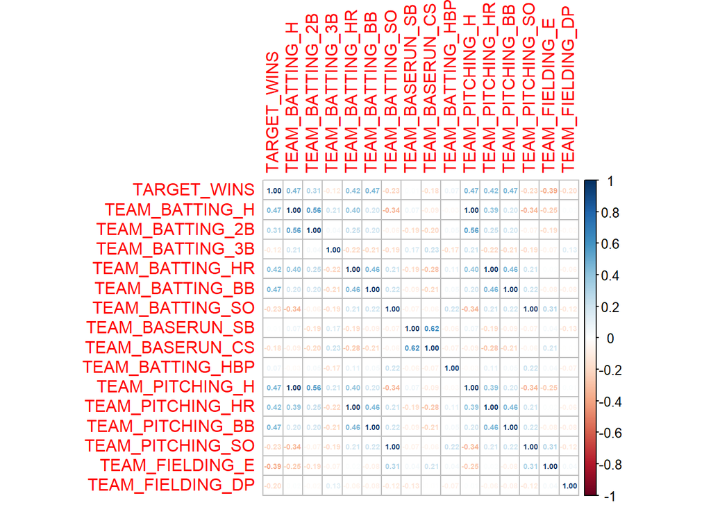

```r
training_cor <- cor(na.omit(baseball_training))
corrplot(training_cor, method = 'number',number.cex=7/ncol(baseball_training))
```

In terms of collinearity, there is large correlation between: * TEAM_PITCHING_H and TEAM_BATTING_H * TEAM_PITCHING_HR and TEAM_BATTING_HR * TEAM_PITCHING_BB and TEAM_BATTING_BB * TEAM_PITCHING_SO and TEAM_BATTING_SO

In the final model, we can explore keeping just 1 of each of these pairs.

In terms of correlation to the TARGET_WINS, TEAM_BATTING_H, TEAM_BATTING_BB, TEAM_PITCHING_H, and TEAM_PITCHING_BB have highest positive correlation. These are also fields with mutual correlation, which is helpful to note going into the model development and data preparation.

Finally, we can create a baseline model, that takes every variable unadjusted. This can act as a baseline to outperform as we iterate with more elaborate models.

```r
lm_baseline <- lm(TARGET_WINS~.,baseball_training)
summary(lm_baseline)
```

```
##
## Call:
## lm(formula = TARGET_WINS ~ ., data = baseball_training)
##
## Residuals:
##      Min       1Q   Median       3Q      Max
## -19.8708  -5.6564  -0.0599   5.2545  22.9274
##
## Coefficients:
##                  Estimate Std. Error t value Pr(>|t|)
## (Intercept)      60.28826   19.67842   3.064  0.00253 **
## TEAM_BATTING_H    1.91348    2.76139   0.693  0.48927
## TEAM_BATTING_2B   0.02639    0.03029   0.871  0.38484
## TEAM_BATTING_3B  -0.10118    0.07751  -1.305  0.19348
## TEAM_BATTING_HR  -4.84371   10.50851  -0.461  0.64542
## TEAM_BATTING_BB  -4.45969    3.63624  -1.226  0.22167
## TEAM_BATTING_SO   0.34196    2.59876   0.132  0.89546
## TEAM_BASERUN_SB   0.03304    0.02867   1.152  0.25071
## TEAM_BASERUN_CS  -0.01104    0.07143  -0.155  0.87730
## TEAM_BATTING_HBP  0.08247    0.04960   1.663  0.09815 .
## TEAM_PITCHING_H  -1.89096    2.76095  -0.685  0.49432
## TEAM_PITCHING_HR  4.93043   10.50664   0.469  0.63946
## TEAM_PITCHING_BB  4.51089    3.63372   1.241  0.21612
## TEAM_PITCHING_SO -0.37364    2.59705  -0.144  0.88577
## TEAM_FIELDING_E  -0.17204    0.04140  -4.155 5.08e-05 ***
## TEAM_FIELDING_DP -0.10819    0.03654  -2.961  0.00349 **
## ---
## Signif. codes:  0 '***' 0.001 '**' 0.01 '*' 0.05 '.' 0.1 ' ' 1
##
## Residual standard error: 8.467 on 175 degrees of freedom
##   (2085 observations deleted due to missingness)
## Multiple R-squared:  0.5501, Adjusted R-squared:  0.5116
## F-statistic: 14.27 on 15 and 175 DF,  p-value: < 2.2e-16
```

### Data Preparation

For Data preparation, there are two things we want to focus on, imputing missing values and making sure the data is ready for the models. The first item we can tackle is finding and replacing missing values. First, we want to find the percentage of missing values. The largest is TEAM_BATTING_HBP with 91% missing data while the second largest variables is TEAM_BASERUN_CS with 33% missing. We also have TEAM_FIELDING_DP with 12% missing, TEAM_BASERUN_SB with roughly 5% and both TEAM_PITCHING_SO and TEAM_BATTING_SO with 4.5% each.

For Team Batting HBP, I was originally going to fill in the NAs with 0 since there is a limited chance that it occurs and seems more like a data input error (the min is 29 but if it is not common should be 0), But since it is an issue that relates to how the games are recorded (this was not recoreded in the early days of baseball) we will get the mean data instead. And for TEAM_FIELDING_DP, I will do the same since it seems to have the same error. For all the other NAs it would make sense to fill in with the mean since there is not too much missing data or the min is 0.0.

Now, another thing we want to check for is if there are any issues with collinearity.

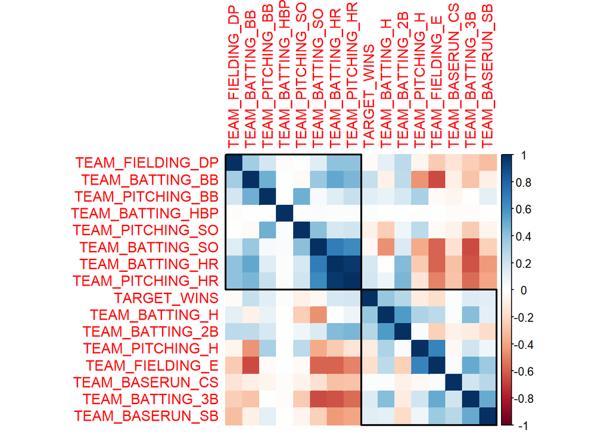

```r
training_cor <- cor(na.omit(baseball_training))
corrplot(training_cor,method = 'color' ,order = 'hclust', addrect = 2)
```

From this heatmap we can see that there is a pairwise relationship between TEAM_PITCHING_HR and TEAM_BATTING_HR (close to 1), but since they are integral to our data, we will not get rid of either.

We need to do the same for baseball eval

And now, we are ready to split the data and build the model.

```r
set.seed(678)

split <- sample.split(baseball_training$TARGET_WINS, SplitRatio = 0.8)
training_set <- subset(baseball_training, split == TRUE)
test_set <- subset(baseball_training, split == FALSE)
```

We split the data into train (80%) and test data (20%)

## Model 1

```r
lm2 <- lm(TARGET_WINS ~ TEAM_BATTING_H + TEAM_BATTING_2B + TEAM_BATTING_3B +
           TEAM_BATTING_HR + TEAM_BATTING_BB + TEAM_BATTING_SO +
           TEAM_BASERUN_SB +  TEAM_PITCHING_H +
            TEAM_PITCHING_BB + TEAM_PITCHING_SO +
           TEAM_FIELDING_E + TEAM_FIELDING_DP, data = training_set)

summary(lm2)
```

```
##
## Call:
## lm(formula = TARGET_WINS ~ TEAM_BATTING_H + TEAM_BATTING_2B +
##     TEAM_BATTING_3B + TEAM_BATTING_HR + TEAM_BATTING_BB + TEAM_BATTING_SO +
##     TEAM_BASERUN_SB + TEAM_PITCHING_H + TEAM_PITCHING_BB + TEAM_PITCHING_SO +
##     TEAM_FIELDING_E + TEAM_FIELDING_DP, data = training_set)
##
## Residuals:
##     Min      1Q  Median      3Q     Max
## -49.627  -8.472   0.049   8.515  56.544
##
## Coefficients:
##                    Estimate Std. Error t value Pr(>|t|)
## (Intercept)      22.2410579  5.9344238   3.748 0.000184 ***
## TEAM_BATTING_H    0.0490852  0.0041243  11.902  < 2e-16 ***
## TEAM_BATTING_2B  -0.0155517  0.0103227  -1.507 0.132100
## TEAM_BATTING_3B   0.0658366  0.0183529   3.587 0.000343 ***
## TEAM_BATTING_HR   0.0568688  0.0110121   5.164 2.68e-07 ***
## TEAM_BATTING_BB   0.0075975  0.0056821   1.337 0.181357
## TEAM_BATTING_SO  -0.0062301  0.0028160  -2.212 0.027066 *
## TEAM_BASERUN_SB   0.0244755  0.0048265   5.071 4.36e-07 ***
## TEAM_PITCHING_H  -0.0009467  0.0003790  -2.498 0.012590 *
## TEAM_PITCHING_BB  0.0023327  0.0036950   0.631 0.527908
## TEAM_PITCHING_SO  0.0025050  0.0008933   2.804 0.005100 **
## TEAM_FIELDING_E  -0.0199673  0.0026315  -7.588 5.17e-14 ***
## TEAM_FIELDING_DP -0.1234703  0.0146783  -8.412  < 2e-16 ***
## ---
## Signif. codes:  0 '***' 0.001 '**' 0.01 '*' 0.05 '.' 0.1 ' ' 1
##
## Residual standard error: 13.23 on 1813 degrees of freedom
## Multiple R-squared:  0.3232, Adjusted R-squared:  0.3187
## F-statistic: 72.15 on 12 and 1813 DF,  p-value: < 2.2e-16
```

```r
vif(lm2)
```

```
##   TEAM_BATTING_H  TEAM_BATTING_2B  TEAM_BATTING_3B  TEAM_BATTING_HR
##         3.780657         2.473079         2.888639         4.667396
##  TEAM_BATTING_BB  TEAM_BATTING_SO  TEAM_BASERUN_SB  TEAM_PITCHING_H
##         5.480579         5.016713         1.804216         3.561706
## TEAM_PITCHING_BB TEAM_PITCHING_SO  TEAM_FIELDING_E TEAM_FIELDING_DP
##         4.540903         2.903665         4.161496         1.333660
```

The most common way to detect multicollinearity is by using the variance inflation factor (VIF), which measures the correlation and strength of correlation between the predictor variables in a regression model.

A value greater than 5 indicates potentially severe correlation between a given predictor variable and other predictor variables in the model.

From our earlier analysis , we already noticed that a correlation exist between TEAM_PITCHING_H * TEAM_BATTING_H and TEAM_BATTING_BB * TEAM_PITCHING_BB and TEAM_PITCHING_SO * TEAM_BATTING_SO

**Model Diagnostics**

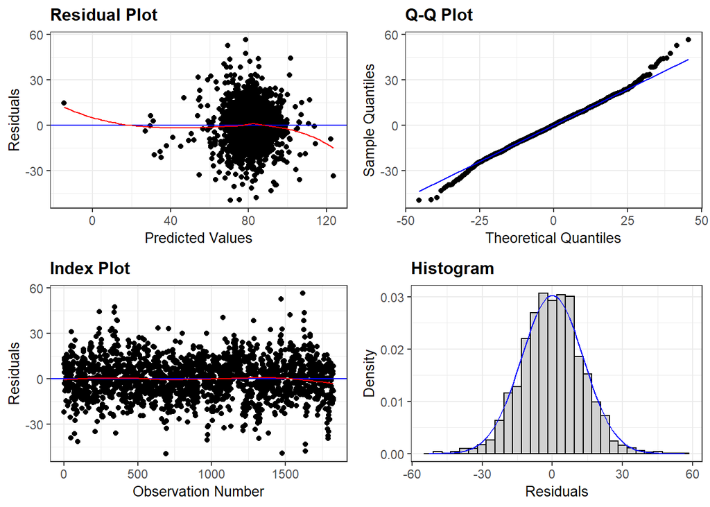

```r
resid_panel(lm2, plots='default', smoother = TRUE)
```

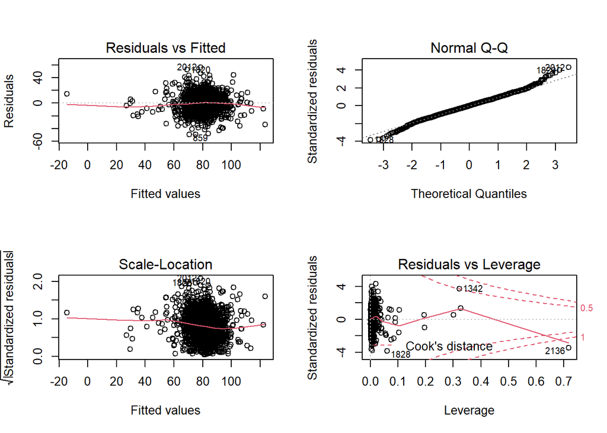

```r
par(mfrow=c(2,2))
plot(lm2)
```

## Model 2

In this model we are going to remove the correlated predictors

```r
lm3 <- lm(TARGET_WINS ~ TEAM_BATTING_H + TEAM_BATTING_2B + TEAM_BATTING_3B +
           TEAM_BATTING_HR + TEAM_BATTING_BB + TEAM_BATTING_SO +
           TEAM_BASERUN_SB + TEAM_FIELDING_E, data = training_set)


summary(lm3)
```

```
##
## Call:
## lm(formula = TARGET_WINS ~ TEAM_BATTING_H + TEAM_BATTING_2B +
##     TEAM_BATTING_3B + TEAM_BATTING_HR + TEAM_BATTING_BB + TEAM_BATTING_SO +
##     TEAM_BASERUN_SB + TEAM_FIELDING_E, data = training_set)
##
## Residuals:
##     Min      1Q  Median      3Q     Max
## -53.078  -9.154   0.002   8.508  60.798
##
## Coefficients:
##                   Estimate Std. Error t value Pr(>|t|)
## (Intercept)      8.0105200  5.7444624   1.394  0.16334
## TEAM_BATTING_H   0.0460224  0.0041572  11.071  < 2e-16 ***
## TEAM_BATTING_2B -0.0134959  0.0103968  -1.298  0.19442
## TEAM_BATTING_3B  0.0813442  0.0183731   4.427 1.01e-05 ***
## TEAM_BATTING_HR  0.0352787  0.0109966   3.208  0.00136 **
## TEAM_BATTING_BB  0.0033577  0.0037405   0.898  0.36949
## TEAM_BATTING_SO  0.0005925  0.0025871   0.229  0.81889
## TEAM_BASERUN_SB  0.0323915  0.0047867   6.767 1.77e-11 ***
## TEAM_FIELDING_E -0.0229460  0.0021954 -10.452  < 2e-16 ***
## ---
## Signif. codes:  0 '***' 0.001 '**' 0.01 '*' 0.05 '.' 0.1 ' ' 1
##
## Residual standard error: 13.53 on 1817 degrees of freedom
## Multiple R-squared:  0.2909, Adjusted R-squared:  0.2877
## F-statistic: 93.15 on 8 and 1817 DF,  p-value: < 2.2e-16
```

```r
vif(lm3)
```

```
##  TEAM_BATTING_H TEAM_BATTING_2B TEAM_BATTING_3B TEAM_BATTING_HR TEAM_BATTING_BB
##        3.674111        2.399495        2.769016        4.451733        2.271714
## TEAM_BATTING_SO TEAM_BASERUN_SB TEAM_FIELDING_E
##        4.050009        1.697371        2.770376
```

**Model Diagnostics**

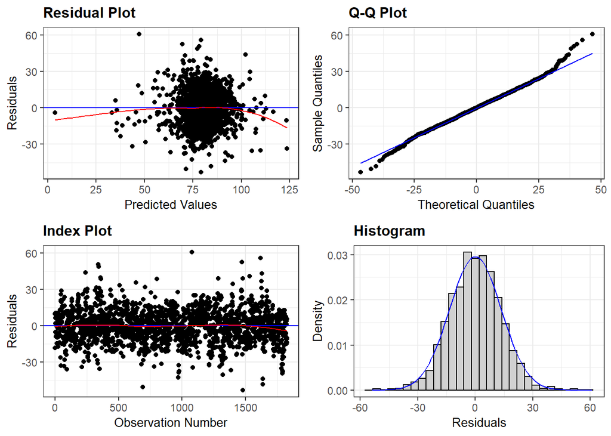

```r
resid_panel(lm3, plots='default', smoother = TRUE)
```

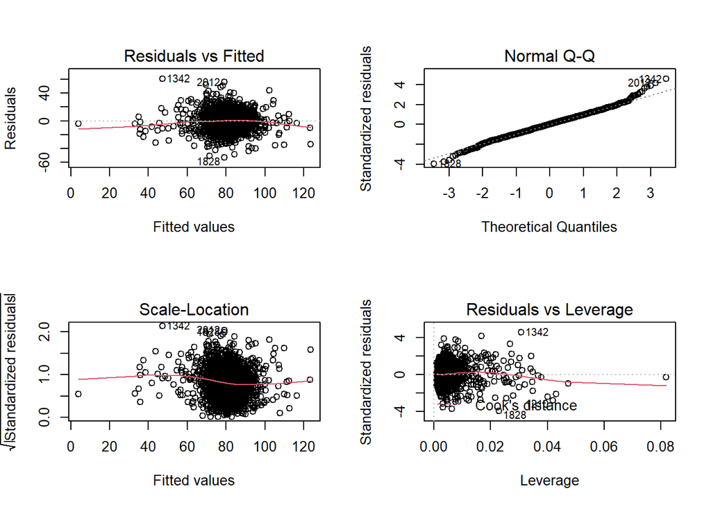

```r
par(mfrow=c(2,2))
plot(lm3)
```

## Model 3

We will do further clean up based on p-value

```r
lm4 <- lm(TARGET_WINS ~ TEAM_BATTING_H + TEAM_BATTING_2B + TEAM_BATTING_3B +
           TEAM_BATTING_HR +  TEAM_BASERUN_SB + TEAM_FIELDING_E, data = training_set)


summary(lm4)
```

```
##
## Call:
## lm(formula = TARGET_WINS ~ TEAM_BATTING_H + TEAM_BATTING_2B +
##     TEAM_BATTING_3B + TEAM_BATTING_HR + TEAM_BASERUN_SB + TEAM_FIELDING_E,
##     data = training_set)
##
## Residuals:
##     Min      1Q  Median      3Q     Max
## -52.943  -9.046  -0.028   8.581  60.883
##
## Coefficients:
##                  Estimate Std. Error t value Pr(>|t|)
## (Intercept)     10.376668   3.450126   3.008  0.00267 **
## TEAM_BATTING_H   0.045480   0.003481  13.067  < 2e-16 ***
## TEAM_BATTING_2B -0.012592   0.010003  -1.259  0.20827
## TEAM_BATTING_3B  0.082751   0.018220   4.542 5.94e-06 ***
## TEAM_BATTING_HR  0.038935   0.008380   4.647 3.62e-06 ***
## TEAM_BASERUN_SB  0.033813   0.004331   7.806 9.86e-15 ***
## TEAM_FIELDING_E -0.024096   0.001771 -13.603  < 2e-16 ***
## ---
## Signif. codes:  0 '***' 0.001 '**' 0.01 '*' 0.05 '.' 0.1 ' ' 1
##
## Residual standard error: 13.52 on 1819 degrees of freedom
## Multiple R-squared:  0.2905, Adjusted R-squared:  0.2882
## F-statistic: 124.2 on 6 and 1819 DF,  p-value: < 2.2e-16
```

```r
vif(lm4)
```

```
##  TEAM_BATTING_H TEAM_BATTING_2B TEAM_BATTING_3B TEAM_BATTING_HR TEAM_BASERUN_SB
##        2.577105        2.222817        2.724804        2.586646        1.390762
## TEAM_FIELDING_E
##        1.804790
```

**Model Diagnostics**

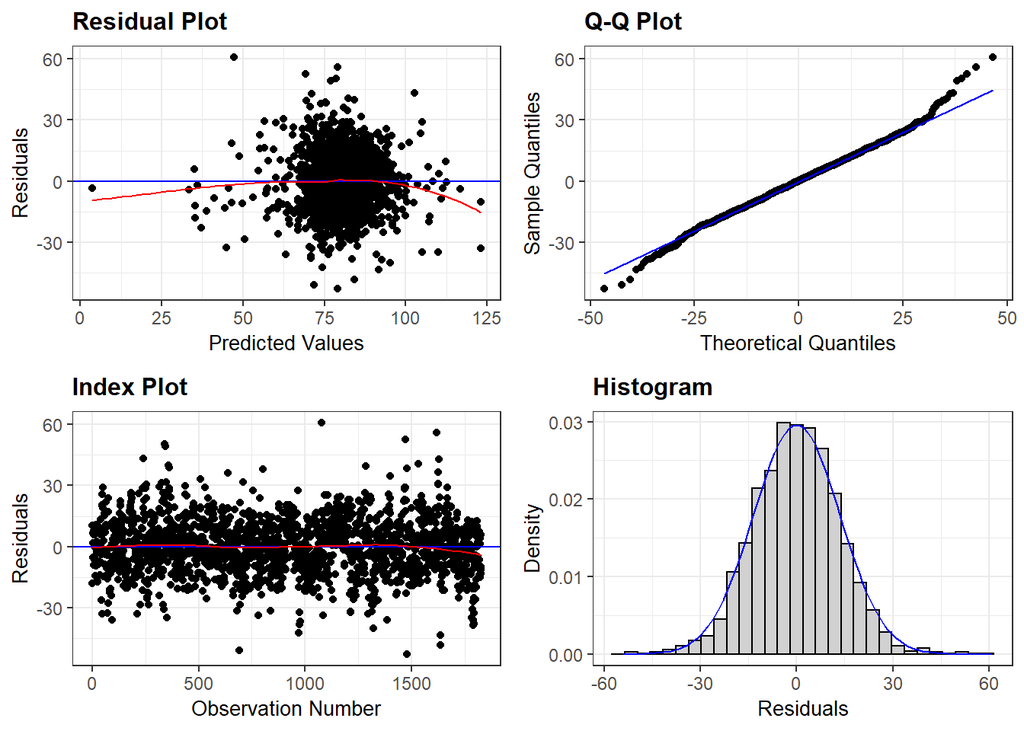

```r
resid_panel(lm4, plots='default', smoother = TRUE)
```

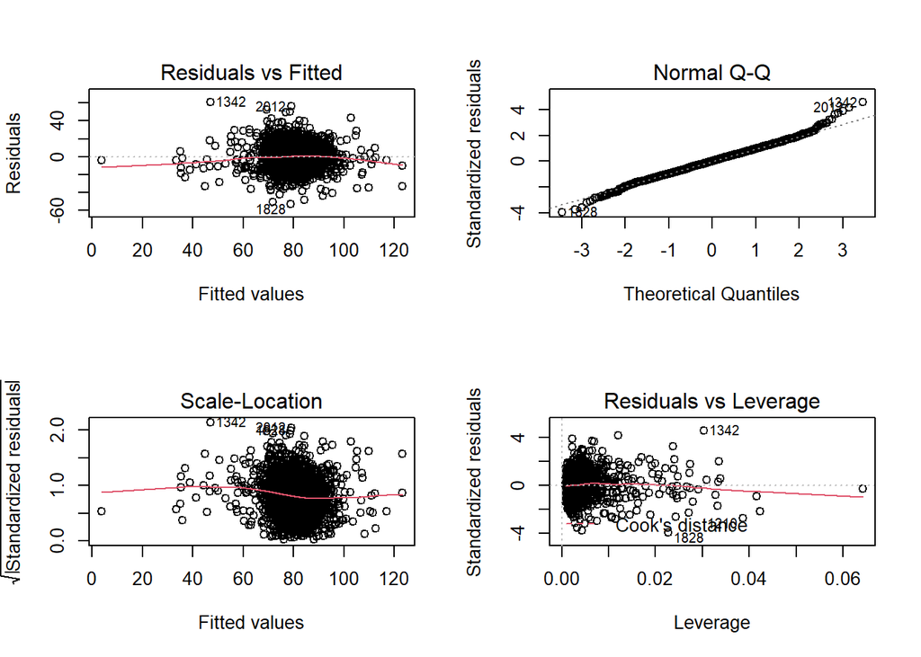

```r
par(mfrow=c(2,2))
plot(lm4)
```

### Select Models

In order to select the best model, we will look at the evaluation metrics (RSE, R-Squared, Adj. R-Squared, F-Statistic, and AIC) for all three models and compare them.

**Extract Model Evaluation Metrics**  
*Model 1*

```r
# extract the rse, r.squared, adj.r.squared, F-statistic, and AIC for model 1
model1_rse <- round(summary(lm2)$sigma, 4)
model1_r_squared <- round(summary(lm2)$r.squared, 4)
model1_adj_r_squared <- round(summary(lm2)$adj.r.squared, 4)
model1_f_statistic <- round(summary(lm2)$fstatistic[1], 4)
model1_aic <- round(AIC(lm2), 4)

model1_metrics <- c(model1_rse, model1_r_squared, model1_adj_r_squared, model1_f_statistic,
                    model1_aic)
```

*Model 2*

```r
# extract the rse, r.squared, adj.r.squared, F-statistic, and AIC for model 2
model2_rse <- round(summary(lm3)$sigma, 4)
model2_r_squared <- round(summary(lm3)$r.squared, 4)
model2_adj_r_squared <- round(summary(lm3)$adj.r.squared, 4)
model2_f_statistic <- round(summary(lm3)$fstatistic[1], 4)
model2_aic <- round(AIC(lm3), 4)

model2_metrics <- c(model2_rse, model2_r_squared, model2_adj_r_squared, model2_f_statistic,
                    model2_aic)
```

*Model 3*

```r
# extract the rse, r.squared, adj.r.squared, F-statistic, and AIC for model 3
model3_rse <- round(summary(lm4)$sigma, 4)
model3_r_squared <- round(summary(lm4)$r.squared, 4)
model3_adj_r_squared <- round(summary(lm4)$adj.r.squared, 4)
model3_f_statistic <- round(summary(lm4)$fstatistic[1], 4)
model3_aic <- round(AIC(lm4), 4)

model3_metrics <- c(model3_rse, model3_r_squared, model3_adj_r_squared, model3_f_statistic,
                    model3_aic)
```

*Combine all metrics*

```r
metrics <- data.frame(model1_metrics, model2_metrics, model3_metrics)
metrics_rownames <- c("RSE", "RSquared", "Adj-RSquared", "F-Statistic", "AIC")
metrics_headers <- c("Model1", "Model2", "Model3")
rownames(metrics) <- metrics_rownames
colnames(metrics) <- metrics_headers
metrics <- metrics %>% kbl() %>% kable_styling()
metrics
```

|  | Model1 | Model2 | Model3 |
| --- | --- | --- | --- |
| RSE | 13.2276 | 13.5252 | 13.5207 |
| RSquared | 0.3232 | 0.2909 | 0.2905 |
| Adj-RSquared | 0.3187 | 0.2877 | 0.2882 |
| F-Statistic | 72.1506 | 93.1534 | 124.1515 |
| AIC | 14627.4980 | 14704.7697 | 14701.5802 |

The model diagnostic plots for all three models appear to be fairly similar. The Q-Q plot shows that the distribution is nearly normal and the residual vs fitted plot also shows no specific patter to worry about. Also, looking at the metrics of all three models, we can see that the values are fairly close. The RSE values are around 13 for all three models and the R-Square and Adj. R-Squared are about 30% for all three models. Furthermore, the AIC (Akaike Information Criteria) for all models are fairly close as well. However, the F-Statistic for Model3 is well above those for models 1 and 2. We can see that as we kept improving the model by selecting features whose p-values are significant, other model metrics remain fairly similar but the F-Statistic improved significantly from model1 to model3. Hence, we select model3 since it has a higher F-Statistic and it’s a simpler model than the others and contains less features that are almost all statistically significant.

### Summary

```r
test_predictions = predict(lm2, newdata=test_set, interval ="predict")


test_set_1 <- cbind(test_set,test_predictions)

# RMSE
paste0("The Root Sqaure Mean Error for model one is: ", round(sqrt(mean((test_set_1$TARGET_WINS - test_set_1$fit)^2)),2))
```

```
## [1] "The Root Sqaure Mean Error for model one is: 12.3"
```

```r
test_predictions = predict(lm3, newdata=test_set, interval ="predict")

test_set_2 <- cbind(test_set,test_predictions)

# RMSE
paste0("The Root Sqaure Mean Error for model two is: ", round(sqrt(mean((test_set_2$TARGET_WINS - test_set_2$fit)^2)),2))
```

```
## [1] "The Root Sqaure Mean Error for model two is: 12.5"
```

```r
test_predictions = predict(lm4, newdata=test_set, interval ="predict")

test_set_3 <- cbind(test_set,test_predictions)

# RMSE
paste0("The Root Sqaure Mean Error for model three is: ", round(sqrt(mean((test_set_3$TARGET_WINS - test_set_3$fit)^2)),2))
```

```
## [1] "The Root Sqaure Mean Error for model three is: 12.51"
```

Linear Model One has the lowest RSME, but overall they are not too far apart, meaning they will perform similar so we will still work with Linear Model Three.

```r
test_predictions = predict(lm4, newdata=baseball_eval, interval ="predict")

baseball_eval_final <- cbind(test_predictions,baseball_eval)
```

Here is the model run with Baseball Eva. Fit is the predicted value, while lwr and upr are the values that fall within a 95% confidence degree.

```r
baseball_eval_final %>%
  kbl() %>%
  kable_paper("hover", full_width = F, html_font = "Times New Roman", font_size = 10) %>%
  kable_styling(bootstrap_options = c("striped", "hover", "condensed"))
```

| fit | lwr | upr | TEAM_BATTING_H | TEAM_BATTING_2B | TEAM_BATTING_3B | TEAM_BATTING_HR | TEAM_BATTING_BB | TEAM_BATTING_SO | TEAM_BASERUN_SB | TEAM_BASERUN_CS | TEAM_BATTING_HBP | TEAM_PITCHING_H | TEAM_PITCHING_HR | TEAM_PITCHING_BB | TEAM_PITCHING_SO | TEAM_FIELDING_E | TEAM_FIELDING_DP | PRED_RUNS | TEAM_FIELDING |
| --- | --- | --- | --- | --- | --- | --- | --- | --- | --- | --- | --- | --- | --- | --- | --- | --- | --- | --- | --- |
| 67.90646 | 41.350848 | 94.46208 | 1209 | 170 | 33 | 83 | 447 | 1080.0000 | 62.0000 | 50.00000 | 62.36842 | 1209 | 83 | 447 | 1080.000 | 140 | 156.000 | 907.3684 | 16.000 |
| 68.40512 | 41.839095 | 94.97114 | 1221 | 151 | 29 | 88 | 516 | 929.0000 | 54.0000 | 39.00000 | 62.36842 | 1221 | 88 | 516 | 929.000 | 135 | 164.000 | 939.3684 | 29.000 |
| 75.77338 | 49.214303 | 102.33247 | 1395 | 183 | 29 | 93 | 509 | 816.0000 | 59.0000 | 47.00000 | 62.36842 | 1395 | 93 | 509 | 816.000 | 156 | 153.000 | 982.3684 | -3.000 |
| 87.08601 | 60.533402 | 113.63861 | 1539 | 309 | 29 | 159 | 486 | 914.0000 | 148.0000 | 57.00000 | 42.00000 | 1539 | 159 | 486 | 914.000 | 124 | 154.000 | 1230.0000 | 30.000 |
| 68.70025 | 42.145847 | 95.25464 | 1445 | 203 | 68 | 5 | 95 | 416.0000 | 123.7033 | 52.31977 | 62.36842 | 3902 | 14 | 257 | 1123.000 | 616 | 130.000 | 771.3914 | -486.000 |
| 67.66162 | 41.094911 | 94.22833 | 1431 | 236 | 53 | 10 | 215 | 377.0000 | 123.7033 | 52.31977 | 62.36842 | 2793 | 20 | 420 | 736.000 | 572 | 105.000 | 957.3914 | -467.000 |
| 79.18169 | 52.572600 | 105.79078 | 1430 | 219 | 55 | 37 | 568 | 527.0000 | 365.0000 | 52.31977 | 62.36842 | 1544 | 40 | 613 | 569.000 | 490 | 146.057 | 1403.6882 | -343.943 |
| 74.48895 | 47.913359 | 101.06453 | 1385 | 158 | 42 | 33 | 356 | 609.0000 | 185.0000 | 52.31977 | 62.36842 | 1626 | 39 | 418 | 715.000 | 328 | 104.000 | 950.6882 | -224.000 |
| 72.38324 | 45.820956 | 98.94553 | 1259 | 177 | 78 | 23 | 466 | 689.0000 | 150.0000 | 52.31977 | 62.36842 | 1342 | 25 | 497 | 734.000 | 226 | 132.000 | 1039.6882 | -94.000 |
| 74.30083 | 47.753170 | 100.84848 | 1397 | 212 | 42 | 58 | 452 | 584.0000 | 52.0000 | 52.31977 | 62.36842 | 1489 | 62 | 482 | 622.000 | 184 | 145.000 | 960.6882 | -39.000 |
| 74.81810 | 48.264837 | 101.37137 | 1427 | 243 | 40 | 50 | 495 | 640.0000 | 64.0000 | 52.31977 | 62.36842 | 1501 | 53 | 521 | 673.000 | 200 | 183.000 | 1032.6882 | -17.000 |
| 84.35026 | 57.800401 | 110.90012 | 1496 | 239 | 55 | 164 | 462 | 670.0000 | 48.0000 | 28.00000 | 62.36842 | 1574 | 173 | 486 | 705.000 | 150 | 178.000 | 1082.3684 | 28.000 |
| 81.85578 | 55.276351 | 108.43522 | 1420 | 223 | 57 | 186 | 511 | 751.0000 | 31.0000 | 21.00000 | 62.36842 | 1494 | 196 | 538 | 790.000 | 137 | 167.000 | 1118.3684 | 30.000 |
| 80.42991 | 53.878734 | 106.98109 | 1460 | 232 | 22 | 176 | 503 | 680.0000 | 27.0000 | 8.00000 | 62.36842 | 1536 | 185 | 529 | 715.000 | 125 | 160.000 | 1056.3684 | 35.000 |
| 78.62753 | 52.069829 | 105.18523 | 1411 | 195 | 22 | 141 | 485 | 665.0000 | 59.0000 | 48.00000 | 62.36842 | 1411 | 141 | 485 | 665.000 | 115 | 114.000 | 1012.3684 | -1.000 |
| 80.02598 | 53.464345 | 106.58761 | 1434 | 192 | 30 | 153 | 434 | 747.0000 | 57.0000 | 46.00000 | 62.36842 | 1434 | 153 | 434 | 747.000 | 146 | 180.000 | 974.3684 | 34.000 |
| 72.80680 | 46.265018 | 99.34858 | 1297 | 204 | 22 | 130 | 491 | 1008.0000 | 84.0000 | 55.00000 | 62.36842 | 1313 | 132 | 497 | 1021.000 | 154 | 126.000 | 1054.3684 | -28.000 |
| 80.92890 | 54.389187 | 107.46861 | 1446 | 284 | 25 | 166 | 565 | 1041.0000 | 77.0000 | 39.00000 | 55.00000 | 1464 | 168 | 572 | 1054.000 | 115 | 172.000 | 1218.0000 | 57.000 |
| 68.74721 | 42.189647 | 95.30478 | 1276 | 162 | 52 | 17 | 383 | 709.3361 | 138.0000 | 52.31977 | 62.36842 | 1351 | 18 | 406 | 799.668 | 301 | 83.000 | 889.6882 | -218.000 |
| 92.24734 | 65.691883 | 118.80279 | 1715 | 322 | 72 | 116 | 527 | 397.0000 | 90.0000 | 83.00000 | 62.36842 | 1816 | 123 | 558 | 420.000 | 232 | 174.000 | 1303.3684 | -58.000 |
| 81.92984 | 55.363319 | 108.49636 | 1520 | 295 | 68 | 49 | 628 | 459.0000 | 77.0000 | 49.00000 | 62.36842 | 1620 | 52 | 669 | 489.000 | 166 | 158.000 | 1269.3684 | -8.000 |
| 84.39483 | 57.839352 | 110.95030 | 1597 | 291 | 38 | 98 | 629 | 563.0000 | 54.0000 | 43.00000 | 62.36842 | 1702 | 104 | 670 | 600.000 | 155 | 174.000 | 1256.3684 | 19.000 |
| 79.90711 | 53.361572 | 106.45265 | 1453 | 256 | 67 | 105 | 653 | 651.0000 | 40.0000 | 41.00000 | 62.36842 | 1559 | 113 | 701 | 698.000 | 179 | 153.000 | 1272.3684 | -26.000 |
| 73.71380 | 47.172487 | 100.25511 | 1378 | 225 | 26 | 118 | 533 | 677.0000 | 18.0000 | 36.00000 | 62.36842 | 1450 | 124 | 561 | 712.000 | 160 | 174.000 | 1046.3684 | 14.000 |
| 84.21949 | 57.678895 | 110.76008 | 1516 | 277 | 24 | 152 | 431 | 902.0000 | 89.0000 | 36.00000 | 54.00000 | 1516 | 152 | 431 | 902.000 | 105 | 164.000 | 1063.0000 | 59.000 |
| 87.19068 | 60.637675 | 113.74369 | 1556 | 288 | 20 | 164 | 474 | 878.0000 | 121.0000 | 32.00000 | 73.00000 | 1556 | 164 | 474 | 878.000 | 102 | 156.000 | 1172.0000 | 54.000 |
| 53.36989 | 26.628296 | 80.11148 | 1499 | 183 | 28 | 3 | 83 | 0.0000 | 123.7033 | 52.31977 | 62.36842 | 5167 | 10 | 286 | 0.000 | 1224 | 146.057 | 738.3914 | -1077.943 |
| 76.81684 | 50.265541 | 103.36815 | 1464 | 263 | 58 | 47 | 385 | 479.0000 | 63.0000 | 66.00000 | 62.36842 | 1540 | 49 | 405 | 504.000 | 232 | 146.000 | 964.3684 | -86.000 |
| 81.49095 | 54.898005 | 108.08389 | 1558 | 318 | 66 | 32 | 634 | 439.0000 | 83.0000 | 64.00000 | 62.36842 | 1639 | 34 | 667 | 462.000 | 218 | 130.000 | 1292.3684 | -88.000 |
| 76.03297 | 49.426308 | 102.63963 | 1502 | 308 | 36 | 39 | 432 | 602.0000 | 45.0000 | 46.00000 | 62.36842 | 1601 | 42 | 460 | 642.000 | 199 | 135.000 | 996.3684 | -64.000 |

[output cut: 229 more lines]